# Optimisation sous contraintes

### Sabaye Fried-junior

Un producteur de cinéma est confronté au problème du planning de son prochain film et vous soumet les tâches qui doivent être effectuées :

| Tâche | Nature | Durée (Jours) | Prérequis (au plus tôt) |
| --- | --- | --- | --- |
| A | Ecriture du scénario | 30 |  |
| B | Casting | 12 | fin A + 15j |
| C | Choix du lieu de tournage | 8 | fin A + 20j |
| D | Découpage technique | 4 | A et C finies |
| E | Décors | 7 | C et D finies |
| F | Tournages extérieurs | 10 | A,B,C et D finies |
| G | Tournages intérieurs | 12 | D, E et F finies |
| H | Synchronisation | 3 | F et G finies |
| I | Montage | 14 | H finie |
| J | Son | 7 | debut I + 3j et fin H |
| K | Mixage | 6 | I et J finies |
| L | Tirage | 1 | fin K + 2j |

# Problématique

Proposer un chemin optimal

## Modélisation

On encode la table en un graphe dirigé pondéré dont les noeuds sont les tâches, les arrêtes représentent les prérequis et la pondération la durée de la tâche correspondant au noeud sortant de l'arrête.

```python
import networkx as nx
import matplotlib.pyplot as plt
```

```python
conda install -c plotly chart-studio
```

```
Solving environment: done

# All requested packages already installed.
```

```python
plt.rcParams["figure.figsize"] = (15, 12)
```

```python
ordo = nx.DiGraph()
```

Les tâches de ce planning nous ont été transmises, en quelque sorte, dans un certain ordre. En effet aucune tâche n'a pour prérequis une tache qui est en dessous d'elle dans le tableau. Ce qui signifie que la première tâche qui devra être effectué est la tâche $\textbf{A}$.

$\textbf{A}$ étant la seule tâche n'ayant pas de prérequis, c'est elle qui sera reliée au noeud $\textbf{Début}$.

La distance entre $\textbf{Début}$ et $\textbf{A}$ sera considéré comme nul. A commeence à $\textbf{J+1}$

```python
ordo.add_weighted_edges_from(
    [   ("Début", "A", 0),
        ("A", "B", 45),
        ("A", "C", 50),
        ("A", "D", 30),
        ("A", "F", 30),
        ("B", "F", 12),
        ("C", "D", 8),
        ("C", "E", 8),
        ("C", "F", 8),
        ("D", "E", 4),
        ("D", "F", 4),
        ("D", "G", 4),
        ("E", "G", 7),
        ("F", "G", 10),
        ("F", "H", 10),
        ("G", "H", 12),
        ("H", "I", 14),
        ("H", "J", 3),
        ("I", "K", 14),
        ("I", "J", 3),
        ("J", "K", 7),
        ("K", "L", 8),
        ("L", "Fin", 1)
    ],
    weight="durée"
)
```

# Représentation graphique

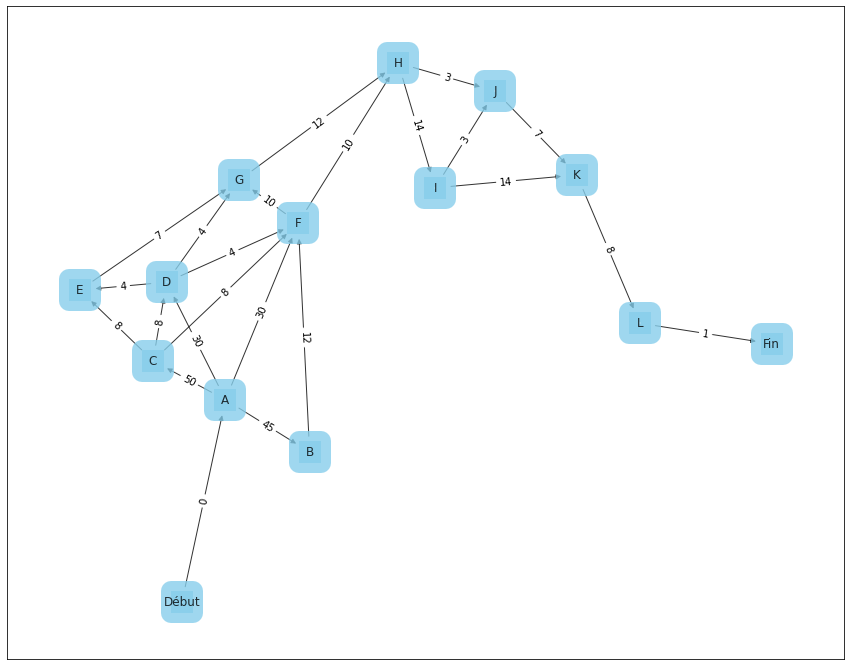

```python
positions = nx.spring_layout(ordo, scale=6)
nx.draw_networkx(ordo, pos=positions,  with_labels=True, node_size=500, node_color="skyblue", node_shape="s", alpha=0.8, linewidths=20)
arretes = nx.get_edge_attributes(ordo, "durée")
textes = nx.draw_networkx_edge_labels(ordo, positions, edge_labels=arretes)
```

Les arrêtes de notre graphe sont données par :

```python
ordo.edges
```

```
OutEdgeView([('Début', 'A'), ('A', 'B'), ('A', 'C'), ('A', 'D'), ('A', 'F'), ('B', 'F'), ('C', 'D'), ('C', 'E'), ('C', 'F'), ('D', 'E'), ('D', 'F'), ('D', 'G'), ('F', 'G'), ('F', 'H'), ('E', 'G'), ('G', 'H'), ('H', 'I'), ('H', 'J'), ('I', 'K'), ('I', 'J'), ('J', 'K'), ('K', 'L'), ('L', 'Fin')])
```

Nous cherchons à établir un planning optimal, ce qui signifie que nous devons déterminer un ordonnancement incluant toutes les tâaches.

Quelles tâches seront effectuées à quelle date et dans quel ordre ?

Lesquelles pourront être éffectuées en parralèlles ?

Quel est l'agencement permettant d'arriver à la fin le plus rapidement possible ?

C'est a ces questions que nous allons tâcher de répondre

La durée (en jours) reliant chacun des noeuds à ses voisins est donné par :

```python
ordo.adj
```

```
AdjacencyView({'Début': {'A': {'durée': 0}}, 'A': {'B': {'durée': 45}, 'C': {'durée': 50}, 'D': {'durée': 30}, 'F': {'durée': 30}}, 'B': {'F': {'durée': 12}}, 'C': {'D': {'durée': 8}, 'E': {'durée': 8}, 'F': {'durée': 8}}, 'D': {'E': {'durée': 4}, 'F': {'durée': 4}, 'G': {'durée': 4}}, 'F': {'G': {'…
```

On va proceder étape par étape et par élimination afin de déterminer un chemin optimal

```python
ordo["Début"]
```

```
AtlasView({'A': {'durée': 0}})
```

Le seul noeud n'ayant pas de prérequis est le Noeud A. La tâche A sera donc la première à être effectuée au jour 1.

```python
ordo.adj["A"]
```

```
AtlasView({'B': {'durée': 45}, 'C': {'durée': 50}, 'D': {'durée': 30}, 'F': {'durée': 30}})
```

Les tâches pouvant être réalisées après la tâche A sont : B,C,D et F.

Les tâches D et F ne pourront pas être réalisées immédiatement car elles ont d'autres prérequis que A.

La première : B à partir de J+45 et la seconde : C, à partir de J+50.

Ces deux tâches seront réalisées en parralèle.

```python
ordo.adj["B"]
```

```
AtlasView({'F': {'durée': 12}})
```

Une fois que la tâche B est réalisée on peut commencer la tâche F mais étant donné que cette dernière à d'autres prérequis que A et B, elle ne peut être réalisée dans l'immédiat.

```python
ordo.adj["C"]
```

```
AtlasView({'D': {'durée': 8}, 'E': {'durée': 8}, 'F': {'durée': 8}})
```

Les tâches pouvant être réalisées après C sont D,E et F.

Les tâches E et F ne pourront pas être réalisées immédiatement car elles ont d'autres prérequis que A,B et C.

C'est donc la tâche D qui sera réalisée à partir de J+58.

La tache D sera achevé à J+62.

```python
ordo.adj["D"]
```

```
AtlasView({'E': {'durée': 4}, 'F': {'durée': 4}, 'G': {'durée': 4}})
```

Les tâches pouvant être réalisées après D sont E,F et G.

La tache G ayant pour prérequis F, elle ne pourra pas être réalisée dans l'immédiat.

Les tâches E et F peuvent être réalisée car leur prérequis sont réalisées.

Les réalisations des tâches E et F pourront donc commencer à J+62.

Les tâches E et F seront réalisés en parralèle.

```python
ordo.adj["E"]
```

```
AtlasView({'G': {'durée': 7}})
```

La tâche E sera achevée avant la tâche F. Elle est reliée à G mais la réalisation de G ne peut se faire immédiatement car elle à pour prérequis la tâche F, qui n'est pas encore achevée.

```python
ordo.adj["F"]
```

```
AtlasView({'G': {'durée': 10}, 'H': {'durée': 10}})
```

Suite à l'achevement de la tâche F à J+72, on peut commencer la réalisation de la tâche G.

La tâche H ne pourra être réalisée à partir de J+72 car son prérequis G n'est pas encore réalisé.

```python
ordo.adj["G"]
```

```
AtlasView({'H': {'durée': 12}})
```

Suite à l'achevement de la tâche G à J+84, la réalisation de la tâche H peut commencer.

La tâche H sera achevée à J+87.

```python
ordo.adj["H"]
```

```
AtlasView({'I': {'durée': 14}, 'J': {'durée': 3}})
```

Suite à l'achevement de la tâche H à J+87, on à deux possibilités. On peut soit commencer la tâche I soit la tâche J.

La tâche I peut commencer à être réalisee immédiatement à J+87 et sera achevée à J+101.

La tâche J ne pourra commencer que 3 jours àpres I, donc à J+90 et sera achevée à J+97.

Les tâches I et j seront réalisée en parralèlles.

```python
ordo.adj["I"]
```

```
AtlasView({'K': {'durée': 14}, 'J': {'durée': 3}})
```

A J+101, la tâche I sera achevée.

La tâche J étant achevée 4 jours plus tôt, on pourra donc commencer la tâche K.

La tâche K sera achevée à J+107.

```python
ordo.adj["K"]
```

```
AtlasView({'L': {'durée': 8}})
```

```python
ordo.adj["L"]
```

```
AtlasView({'Fin': {'durée': 1}})
```

La tâche L pourra donc être réalisée à partir de J+109, pour une durée de 1 jour.

Le chemin optimal entre le Début et la Fin est donc de 110 jours.

$\textbf{Résumé :}$

La première tâche à effectuer à J+1 est la tâche $\textbf{A}$.

Les tâches suivantes pouvant être effectuer sont les tâches : $\textbf{B}$, $\textbf{C}$, $\textbf{D}$ et $\textbf{F}$ mais seul $\textbf{B}$ et $\textbf{C}$ sont réalisables car elle n'ont pour prérequis que $\textbf{A}$ qui est déja réalisée.

Ainsi à $\textbf{J+45}$ on peut commencer la tâche $\textbf{B}$ et 5 jours plus tard commencer la tâche $\textbf{C}$. Ces deux tâches seront donc éffectuées en parralèlle.

À $\textbf{J+58}$ quand la tâche $\textbf{C}$ sera achevée on pourra ainsi commencer la tâche $\textbf{D}$. Cette dernière durant 4 jours et étant un prérequis pour $\textbf{E}$, c'est à $\textbf{J+62}$ que l'on pourra commencer la tâche $\textbf{E}$. Le même jour, on pourra également commencer la tâche $\textbf{F}$. Ces deux tâches seront elles aussi éffectuées en parralèle.

10 jours plus tard, à $\textbf{J+72}$, quand la tâche $\textbf{F}$ sera effectuée, on pourra commencer la tâche $\textbf{G}$.

Pour la suite des tâches on attend simplement que la précedente soit éffectuée.

Ces résultats sont ainsi résumé dans le tableau suivant :

| Date début | Tâches à commencer | Durée pour finir la tâche | Date Fin |
| --- | --- | --- | --- |
| J+1 | A : Ecriture du scénario | 30 jours | J+30 |
| J+45 | B : Casting | 12 jours | J+57 |
| J+50 | C : Choix du lieu de tournage | 8 jours | J+58 |
| J+58 | D : Découpage technique | 4 jours | J+62 |
| J+62 | E : Décors | 7 jours | J+69 |
| J+62 | F : Tournages extérieurs | 10 jours | J+72 |
| J+72 | G : Tournages intérieurs | 12 jours | J+84 |
| J+84 | H : Synchronisation | 3 jours | J+87 |
| J+87 | I : Montage | 14 jours | J+101 |
| J+90 | J : Son | 7 jours | J+97 |
| J+101 | K : Mixage | 6 jours | J+107 |
| J+109 | L : Tirage | 1 jour | J+109 |
| J+110 | Fin |  | J+110 |

## Question ouverte : Gantt Chart

On défini s comme étant le jour de départ.

Ainsi ce jour pourra être modifier facilement, en fonction des besoins.

Pour l'illustration, on décide de fixer la date de début au 1er Janvier 2021.

```python
from datetime import datetime, timedelta
s = '2021/01/01'
date = datetime.strptime(s, "%Y/%m/%d")
modified_date = date + timedelta(days=1)
datetime.strftime(modified_date, "%Y/%m/%d")
```

```
'2021/01/02'
```

```python
import plotly.figure_factory as ff
import seaborn as sns

current_palette = sns.color_palette()


df = [dict(Task="A : Ecriture du scénario", Start=date, Finish=date + timedelta(days=30), Resource='A'),
      dict(Task="B : Casting", Start=date + timedelta(days=45), Finish=date + timedelta(days=57), Resource='B'),
      dict(Task="C : Choix du lieu de tournage", Start=date + timedelta(days=50), Finish=date + timedelta(days=58), Resource='C'),
     dict(Task="D : Découpage technique	", Start=date + timedelta(days=58), Finish=date + timedelta(days=62), Resource='D'),
      dict(Task="E : Décors", Start=date + timedelta(days=62), Finish=date + timedelta(days=69), Resource='E'),
      dict(Task="F : Tournages extérieurs	", Start=date + timedelta(days=62), Finish=date + timedelta(days=72), Resource='F'),
     dict(Task="G : Tournages intérieurs", Start=date + timedelta(days=72), Finish=date + timedelta(days=84), Resource='G'),
      dict(Task="H : Synchronisation", Start=date + timedelta(days=84), Finish=date + timedelta(days=87), Resource='H'),
      dict(Task="I : Montage", Start=date + timedelta(days=87), Finish=date + timedelta(days=101), Resource='I'),
     dict(Task="J : Son	", Start=date + timedelta(days=90), Finish=date + timedelta(days=97), Resource='J'),
      dict(Task="K : Mixage", Start=date + timedelta(days=101), Finish=date + timedelta(days=107), Resource='K'),
     dict(Task="L : Tirage	", Start=date + timedelta(days=109), Finish=date + timedelta(days=110), Resource='L')]

fig = ff.create_gantt(df,colors=sns.color_palette("Paired"),
                      show_colorbar=True, bar_width=0.2, showgrid_x=True, showgrid_y=True)
fig.show()
```

[interactive chart not shown]